# Project 2: Analysis of the IMDb Top 1000 Worst Rated Titles

2024-11-14

# Introduction

This project will analyze the IMDb Top 1000 Worst Rated Titles dataset, which lists the lowest-rated movies and TV shows on IMDb with over 10,000 votes. This dataset is sourced from Kaggle, and it is updated daily by OctopusTeam. You can find the dataset [here](https://www.kaggle.com/datasets/octopusteam/imdb-top-1000-worst-rated-titles?resource=download).

I chose this dataset because it offers insights into the factors contributing to poor audience reception. By exploring patterns in genre, release year, and rating, we can investigate trends and identify potential reasons why certain titles fail to resonate with audiences. This analysis may also reveal insights about the correlation between genres and their ratings, shedding light on audience preferences.

[figure not shown]

Image Source: Wikimedia Commons

## Dataset Import and Processing

The dataset’s usability rating on Kaggle (10/10) means it is ready for analysis with minimal processing required. It can be imported into R directly, and if necessary, minor adjustments can be done to help with analysis. The only challege faced was that multiple genres were listed per title, meaning that “Comedy, Drama” would be considered different than “Drama, Comedy”, even though they should be the same. To account for this, a second variable (genre_subset_data) was made where each of the genres were split into this own row. While this means the same title may now have 3 rows, it still faithfully shows relationships between the genre and numerical variables. For that reason, the genre_subset_data should only be used in bivariate analysis where genre is involved.

## Variables of Interest

Key variables investigated include:

**Genres**: To see if certain genres are overrepresented in low ratings.

**Average Rating**: To analyze the distribution of ratings.

**Number of Votes**: To explore if vote count correlates with ratings.

**Release Date**: To explore if certain release dates ended up more often on this list than others

This exploration will help identify potential trends and audience behaviors that influence IMDb ratings.

# Data Preparation

The data was obtained from Kaggle, which provided an already well-structured and cleaned dataset and it was largely pre-processed, meaning there were no significant issues with missing values (NA), factors, or date formatting. I did a quick check to ensure the data types matched my analysis needs, but overall, the dataset was good to go as is.

One of the benefits of using a dataset from Kaggle is that it often comes with clear documentation and formatting, minimizing the usual challenges of data preparation, like handling inconsistencies or dealing with null values. This allowed me to jump directly into the analysis without needing to spend any additional time in processing.

# Variable Descriptions

## Description of Variables in the Cleaned Dataset

| Variable | Type | Description |
| --- | --- | --- |
| genres | Character | The genre of the movie |
| averageRating | Numeric | Average rating of the movie from user votes |
| numVotes | Integer | Total number of votes received for the movie |
| releaseYear | Integer | Year the movie was released |

## Descriptive Statistics on variables

```
## Variable: title
## < table of extent 0 >
## -------------------------
## Variable: genres
##
##      Action   Adventure   Animation   Biography      Comedy       Crime
##         352         217          20          10         391         143
## Documentary       Drama      Family     Fantasy   Game-Show     History
##          17         300          89         118           2           7
##      Horror       Music     Musical     Mystery  Reality-TV     Romance
##         288          21           9         137           6         117
##      Sci-Fi       Short       Sport   Talk-Show    Thriller         War
##         115           2          15           1         215           5
##     Western
##           2
## -------------------------
## averageRating
##  Mean: 4.33
##  Standard Deviation: 0.89
##
## Min, 1st Q, Median, Mean 3rd Q, Max:
##  1 4 4.65 4.332 5 5.2
## -------------------------
## numVotes
##  Mean: 34263.2
##  Standard Deviation: 35912.16
##
## Min, 1st Q, Median, Mean 3rd Q, Max:
##  10005 13463 21560.5 34263.2 41126.75 340974
## -------------------------
## releaseYear
##  Mean: 2009.38
##  Standard Deviation: 10.69
##
## Min, 1st Q, Median, Mean 3rd Q, Max:
##  1957 2003 2011 2009.38 2018 2024
## -------------------------
```

# Univariate Analyses

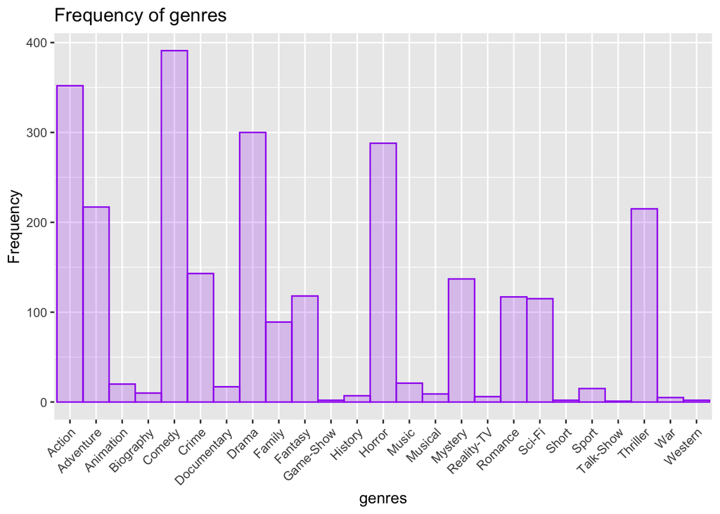

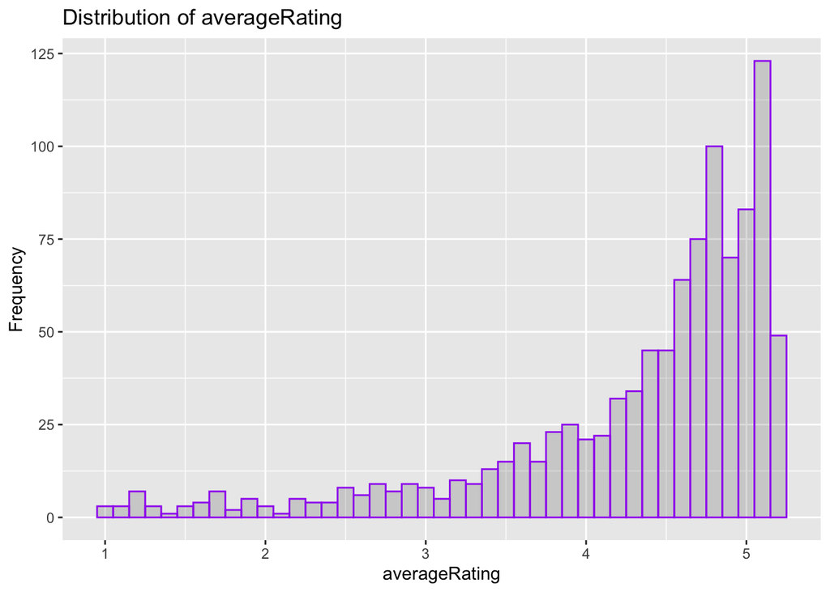

The mean average rating in the dataset is 4.33, with a standard deviation of 0.89. The maximum value is 5.2, the median 4.65, while the minimum value is 1.

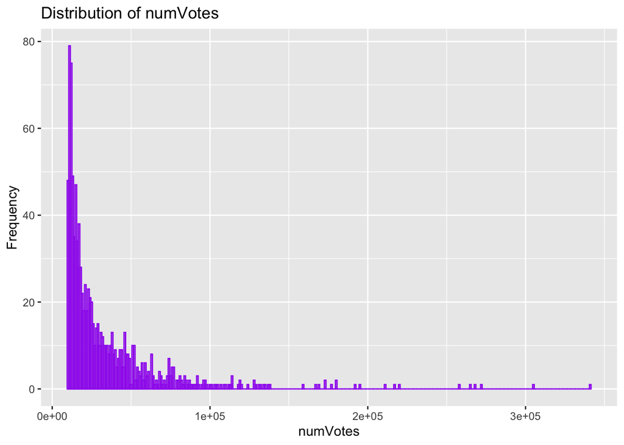

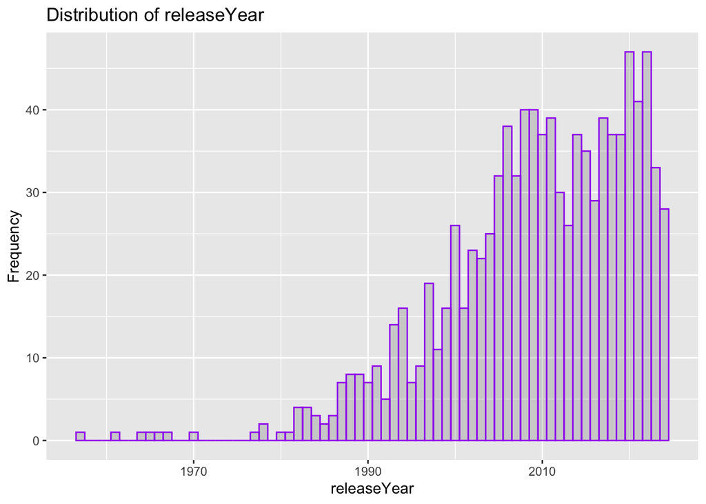

The mean release date year in the dataset is 2009.38, with a standard deviation of 10.69. The maximum value is 2024, the median 2011, while the minimum value is 1957.

# Multivariate Analyses

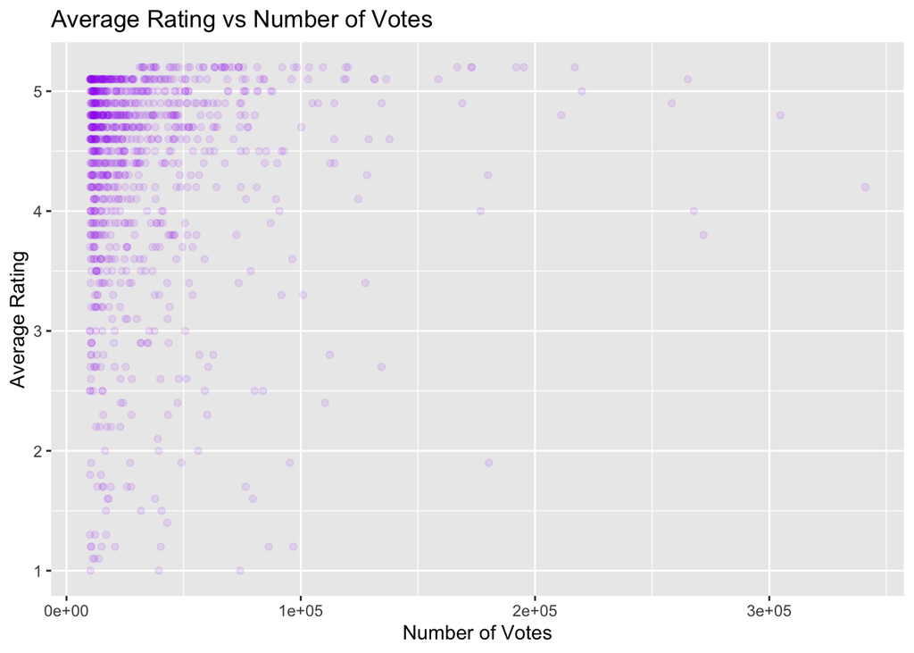

The correlation coeffecient between averageRating and numVotes is 0.06. This shows a negligible slightly positive correlation between the two, meaning that titles with more votes overall had higher ratings but realistically the number of votes did not have a meaningful impact on the averageRating.

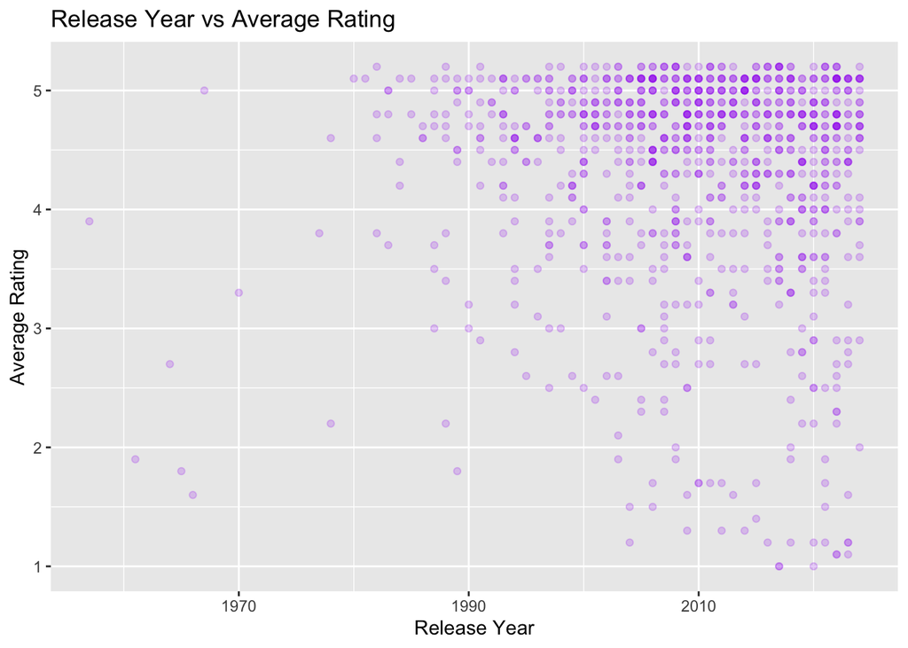

The correlation coeffecient between releaseYear and averageRating is -0.03. This shows a negligible slightly negative correlation between the two, meaning that release year had virtually no impact on the averageRating.

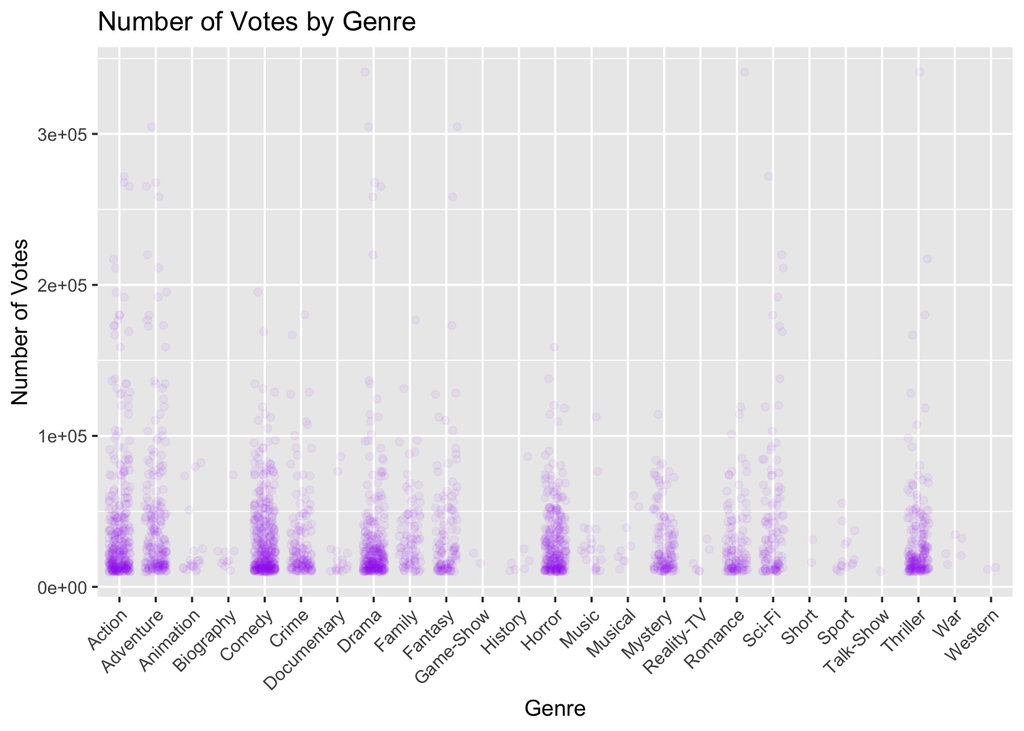

The plot shows that in general Action, Adventure, Comedy, Crime, Drama, Horror, Mystery, Romance, Sci-Fi, and Thriller had more votes than other genres in the dataset.

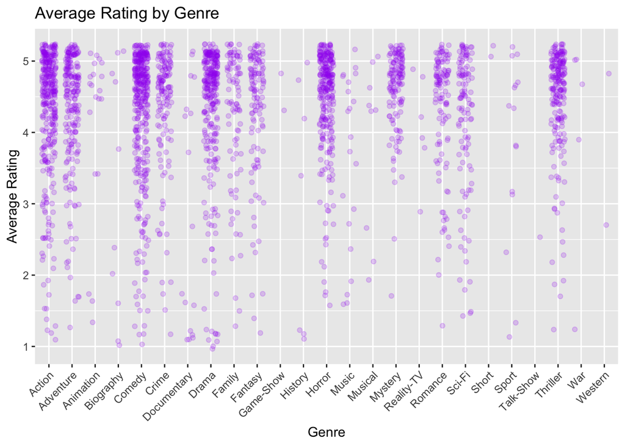

This plot shows that Action, Adventure, Comedy, Drama, Horror, and Thriller had the most consistent votes for higher average rating as they are the most concentrated and consistently higher.

# Reproducibility Resources

### Project Files and Data

All materials used in the production of this analysis can be found on my [github repo](https://github.com/kaustubhduddala/SDS_313/tree/main/Homework_5). To reproduce all material on your own simply download the Project_2.Rmd file as well as the data.csv file either from the github (both included) or the Kaggle link at the top of this report.

# Choice Elements

**Create at least two new variables of interest** Two new variables were made. The variable_info variable was created to store details about each variable, making it easy to present them in a table. genre_subset_data was made to separate genres into individual rows, enabling multivariate analysis with the other variables, since without it each unique combination of genres would be treated as its own category.

**Format or parse at least one string variable of interest** The genre_subset_data variable was created by parsing a the genre string variable in the dataset. This parsing split the rows to ensure each row contains a single genre, allowing for comparisons in the “Average Rating by Genre” and “Number of Votes by Genre” graphs.

**Write and use a user-written function with at least 2 arguments to either process the data or carry out some analysis** The function univariate() was made with 3 arguments to carry out analysis on each of the univariate graphs so that the code could be written once and then used twice for each type, therefore making it more effecient than writing out the code for each analysis.

**Use an if statement to either process the data or carry out some analysis** In the univariate() function, an if statement was used to determine whether the variable being analyzed was numeric or categorical. This then adjusts the graph type to either a histogram for numeric data or a bar graph for categorical data.

**Use a loop to process the data or carry out some analysis that could not be more efficiently achieved without one** A for loop was used in Variable Descriptions to list out and show descriptive statistics for the various variables that would be explored in the report.

# Conclusion

In conclusion, this analysis of the IMDb Top 1000 Worst Rated Titles dataset reveals key insights into the characteristics of poorly-rated movies and shows. One of the findings is that while genres such as Action, Comedy, Drama, Horror, and Thriller are prevalent among low-rated titles, they also tend to attract larger audiences, as indicated by the high number of votes. This suggests that popular genres are not immune to poor ratings, potentially due to higher expectations or the volume of content produced in these categories.

The correlation analysis between average rating and number of votes shows a negligible positive relationship, indicating that popularity, as measured by votes, does not necessarily lead to higher ratings. The relationship between release year and average rating is also minimal, meaning that titles from different eras do not differ significantly in terms of their likelihood of being poorly rated. There is, however, a noticeable concentration of low ratings in more recent years, which could reflect evolving audience expectations or shifts in cinematic trends.

These findings provide a nuanced understanding of the factors associated with low IMDb ratings, offering insights into audience preferences across genres and time periods. This analysis serves as a foundation for further exploration into why certain titles fail to resonate with viewers, which could be valuable for both movie producers and marketers in understanding and predicting audience reception.

# References

[1] https://www.kaggle.com/datasets/octopusteam/imdb-top-1000-worst-rated-titles/data

[2] https://upload.wikimedia.org/wikipedia/commons/6/69/IMDB_Logo_2016.svg